# PK Simulations of 100 mg IV in Patients with Modified CL and F

Neha Mehta

2015-12-09

```r
# required libraries
library("PKPDmisc")
library("ggplot2")
library("dplyr")
library("mlxR")
library("reshape2")
library("knitr")
```

```r
knitr::opts_chunk$set(echo=FALSE)
```

# 1. PK profile of 100 mg IV bolus administered as a single dose.

##### (PK profile of 100 mg IV bolus (SD), CL = 0.1 L/hr, V = 1 L)

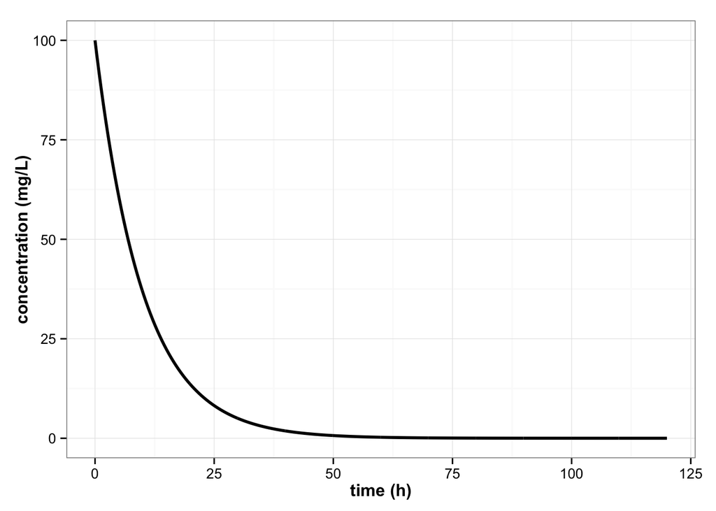

### 1a. Patient’s clearance decreases by 25%.

##### (PK profile of 100 mg IV bolus (SD), CL = 0.075 L/hr, V= 1 L)

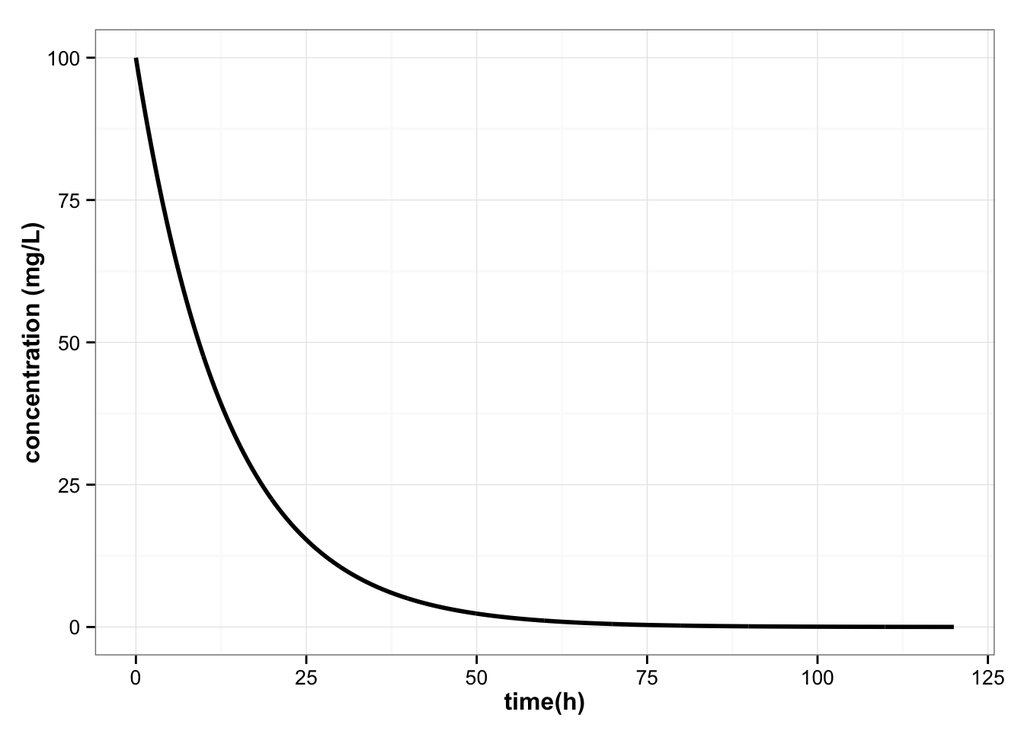

### 1b. Patient’s clearance decreases by 50%.

##### (PK profile of 100 mg IV bolus (SD), CL = 0.05 L/hr, V = 1 L)

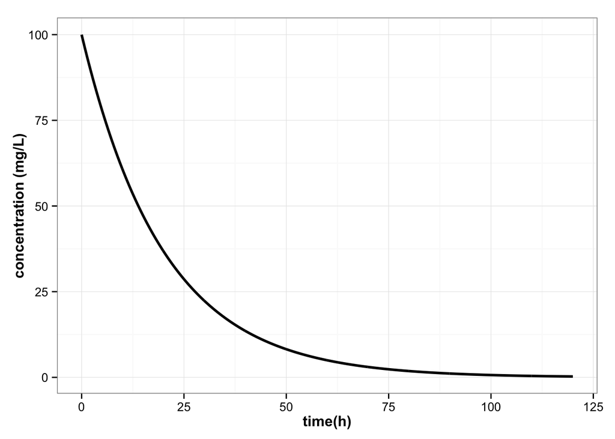

### 1c. Overlay PK profiles of patient with normal clearance and decreased clearance

##### (PK profile of 100 mg IV bolus (SD), V = 1 L, CL = 0.1 L/hr, 0.05 L/hr, 0.075 L/hr)

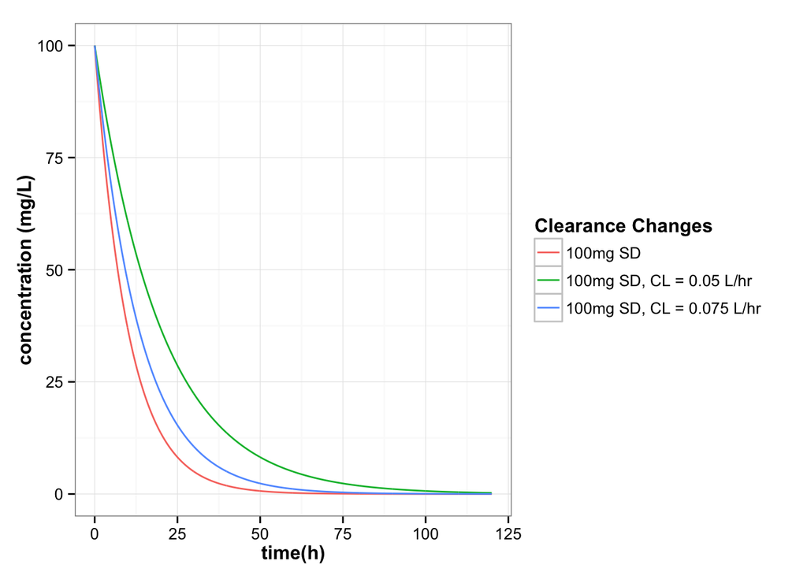

# 2. PK profile of 100 mg IV bolus administered every 6 hours

##### (PK profile of 100 mg IV bolus, LD (t = 0), MD (q= 6 hr), CL = 0.1 L/hr, V = 1 L)

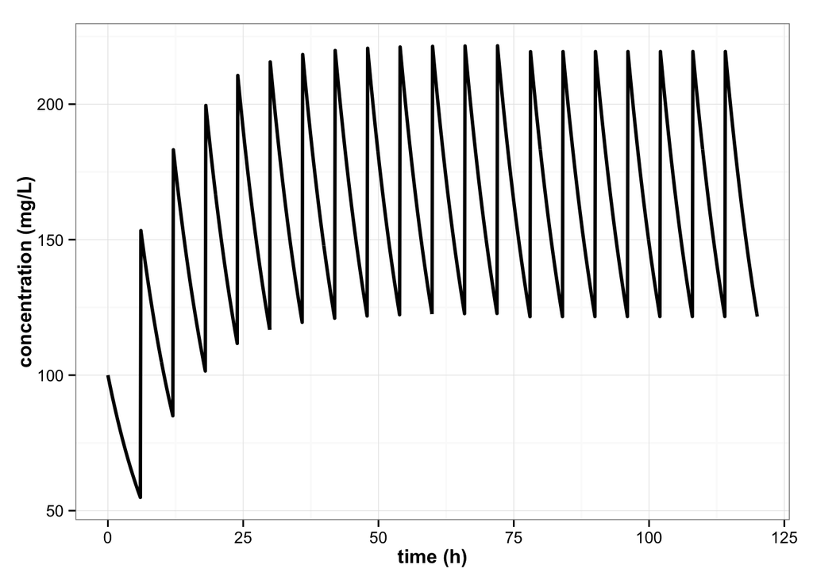

### 2a. Patient’s clearance decreases by 25%.

##### (PK profile of 100 mg iv bolus, LD (t=0), MD (q=6hr), CL = 0.075 L/hr, V= 1 L)

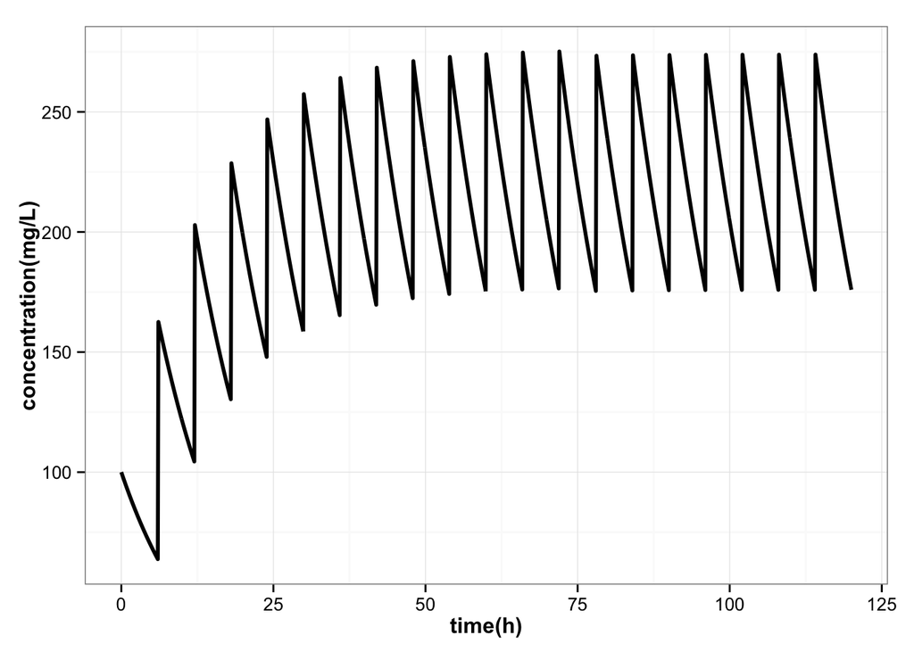

### 2b. Patient’s clearance decreases by 50%.

##### (PK profile of 100 mg IV bolus, LD (t=0), MD (q=6hr), CL = 0.05 L/hr, V= 1 L)

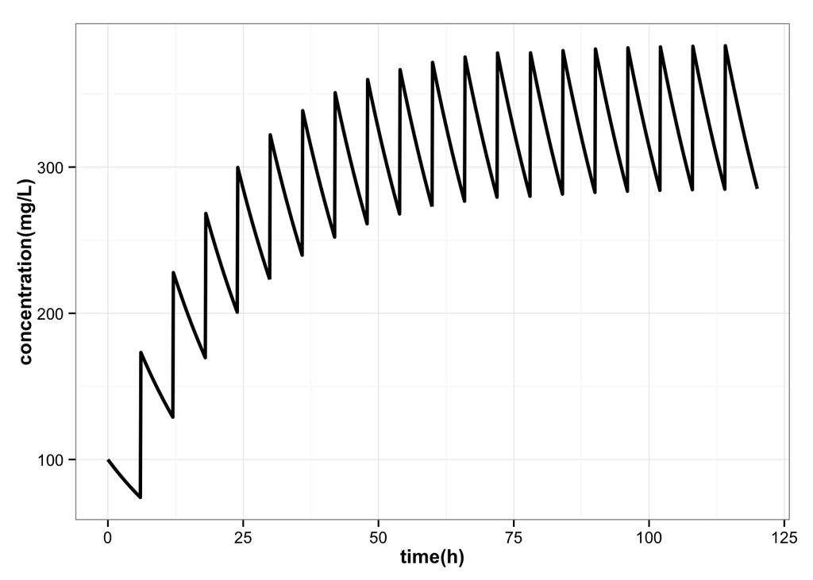

### 2c. Overlay PK profiles plot of patient with normal clearance and decreased clearance

##### (PK profile of 100 mg IV bolus, LD(t=0), MD (q=6hr), V = 1 L, CL = 0.1 L/hr, 0.05 L/hr, 0.075 L/hr)

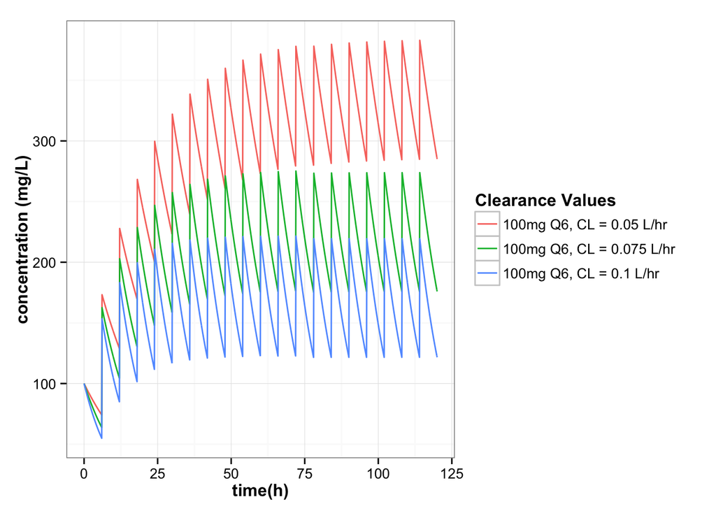

# 3. PK profile of 100 mg IV bolus given every 12 hours

##### (PK profile of 100 mg IV bolus, LD (t=0), MD (q=12 hr), CL =0.1 L/hr, V = 1 L)

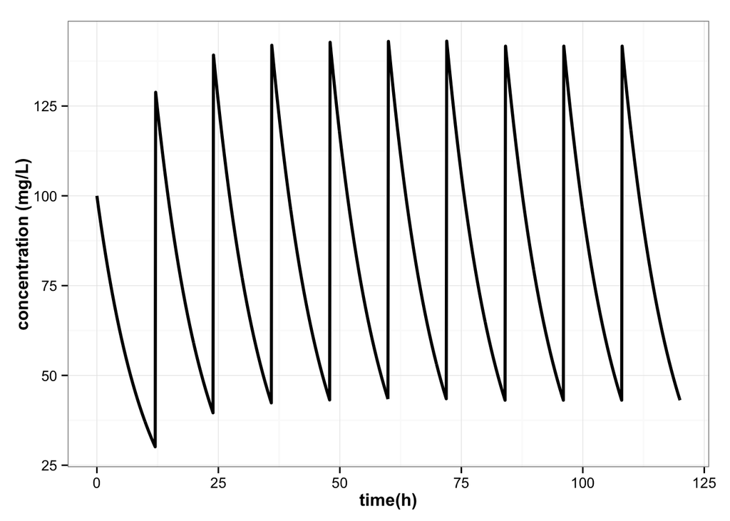

### 3a. Patient’s clearance decreases by 25%.

##### (PK profile of 100 mg IV bolus, LD (t=0), MD (q=12hr), CL = 0.075 L/hr, V= 1 L)

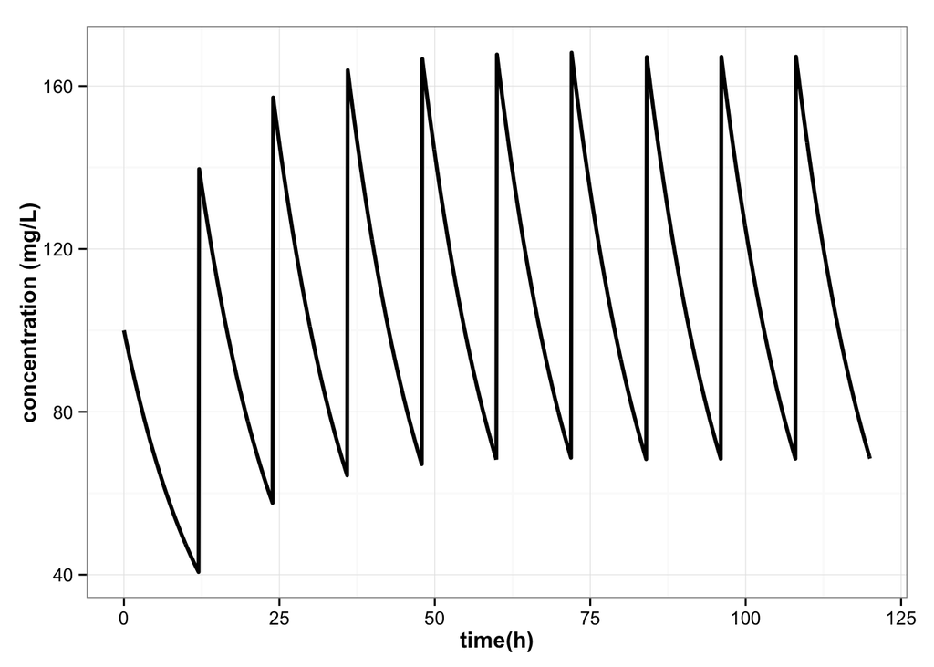

### 3b. Patient’s clearance decreases by 50%.

##### (PK profile of 100 mg IV bolus, LD (t=0), MD (q=12hr), CL = 0.05 L/hr, V= 1 L)

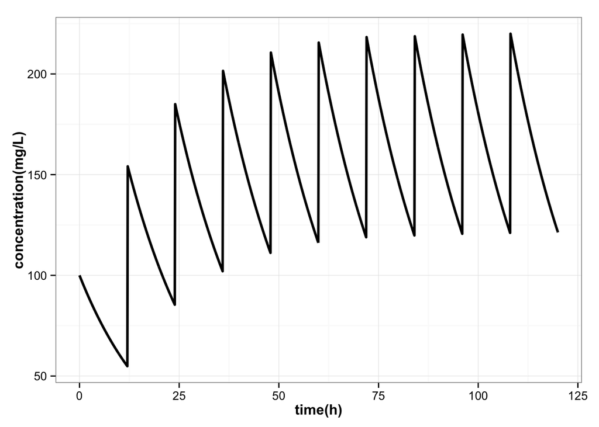

### 3c. Overlay PK profiles of patient with normal clearance and decreased clearance

##### (PK profile of 100 mg iv bolus, LD(t=0), MD (q=12hr), V = 1 L, CL = 0.1 L/hr, 0.05 L/hr, 0.075 L/hr)

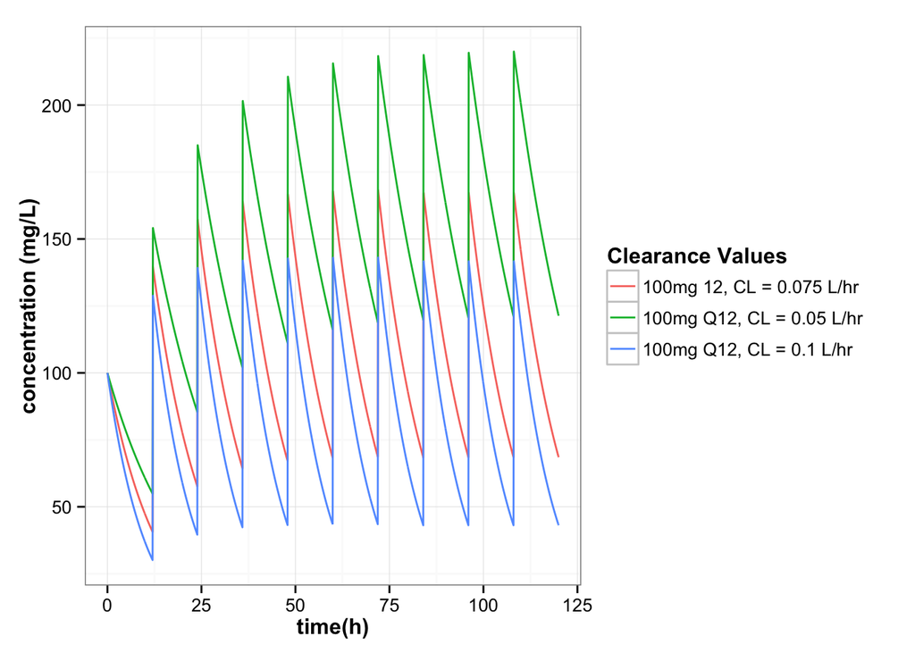

# 4. PK profile of 100 mg IV bolus administered every 24 hours

##### (PK profile of 100 mg IV bolus, LD (t=0), MD (q=24 hr), CL=0.1 L/hr, V = 1L)

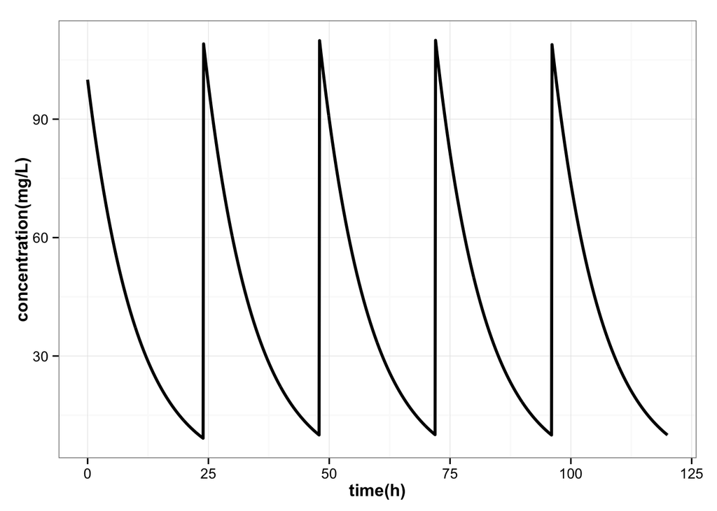

### 4a. Patient’s clearance decreases by 25%.

##### (PK profile of 100 mg IV bolus, LD (t=0), MD (q=24hr), CL = 0.075 L/hr, V= 1 L)

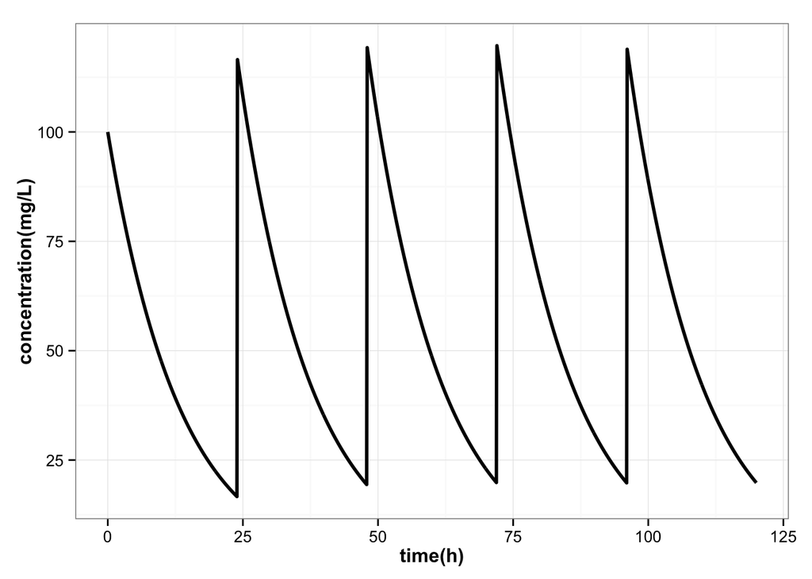

### 4b. Patient’s clearance decreases by 50%.

##### (PK profile of 100 mg IV bolus, LD (t=0), MD (q=24hr), CL = 0.05 L/hr, V= 1 L)

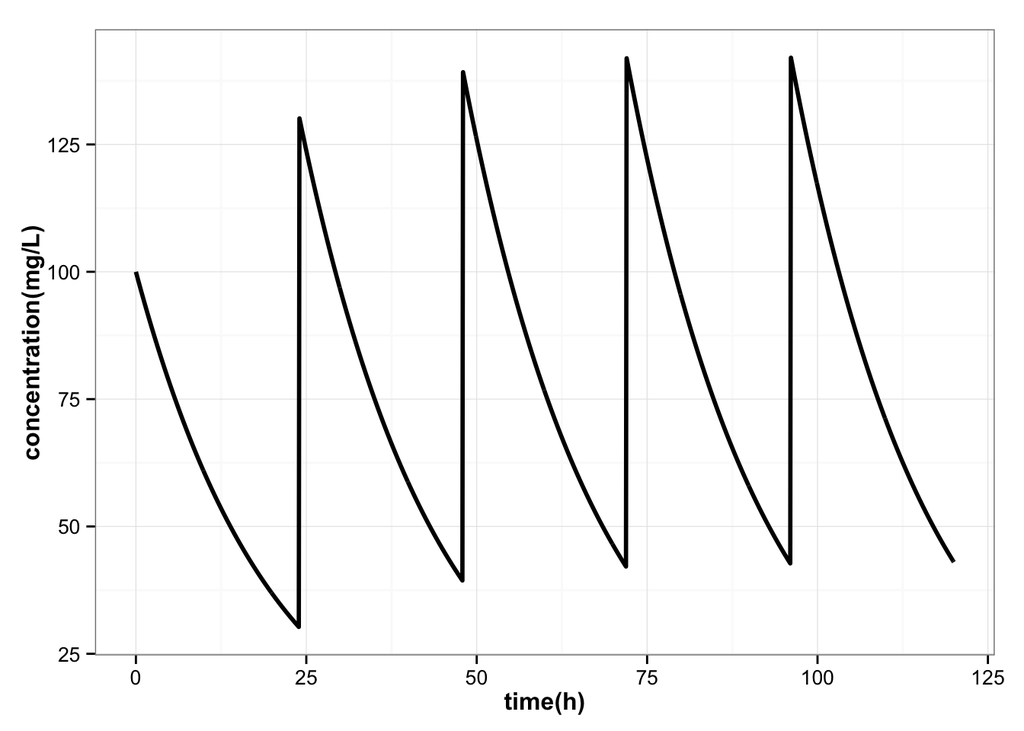

### 4c. Overlay PK profiles of patient with normal clearance and decreased clearance

##### (PK profile of 100 mg iv bolus, LD(t=0), MD (q=24hr), V = 1 L, CL = 0.1 L/hr, 0.05 L/hr, 0.075 L/hr)

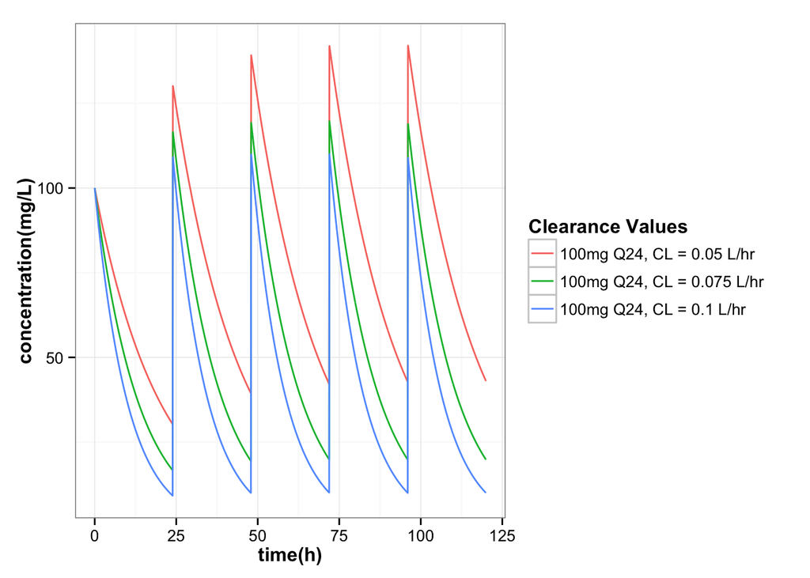

# 5. Overlay plots of all dosing intervals

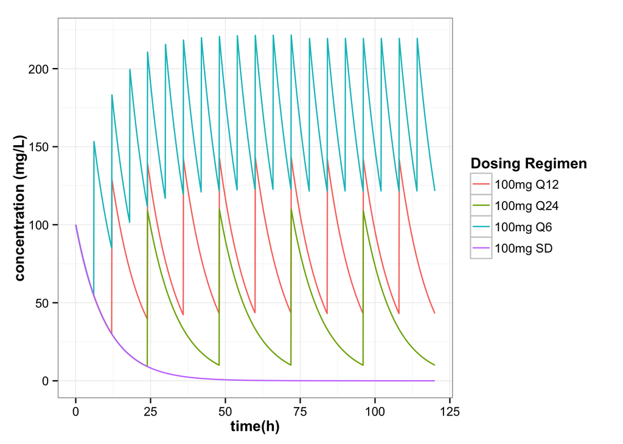

```
##  setting  value
##  version  R version 3.2.2 (2015-08-14)
##  system   x86_64, darwin13.4.0
##  ui       X11
##  language (EN)
##  collate  en_US.UTF-8
##  tz       America/New_York
##  date     2015-12-09
```

```
## Packages ------------------------------------------------------------------
```

```
##  package    * version  date       source
##  assertthat   0.1      2013-12-06 CRAN (R 3.2.0)
##  colorspace   1.2-6    2015-03-11 CRAN (R 3.2.0)
##  DBI          0.3.1    2014-09-24 CRAN (R 3.2.0)
##  devtools     1.9.1    2015-09-11 CRAN (R 3.2.0)
##  digest       0.6.8    2014-12-31 CRAN (R 3.2.0)
##  dplyr      * 0.4.3    2015-09-01 CRAN (R 3.2.0)
##  evaluate     0.8      2015-09-18 CRAN (R 3.2.0)
##  formatR      1.2.1    2015-09-18 CRAN (R 3.2.0)
##  ggplot2    * 1.0.1    2015-03-17 CRAN (R 3.2.0)
##  gtable       0.1.2    2012-12-05 CRAN (R 3.2.0)
##  htmltools    0.2.6    2014-09-08 CRAN (R 3.2.0)
##  knitr      * 1.11     2015-08-14 CRAN (R 3.2.2)
##  labeling     0.3      2014-08-23 CRAN (R 3.2.0)
##  lazyeval     0.1.10   2015-01-02 CRAN (R 3.2.0)
##  magrittr     1.5      2014-11-22 CRAN (R 3.2.0)
##  MASS         7.3-44   2015-08-30 CRAN (R 3.2.0)
##  memoise      0.2.1    2014-04-22 CRAN (R 3.2.0)
##  mlxR       * 2.2.0    2015-05-31 CRAN (R 3.2.0)
##  munsell      0.4.2    2013-07-11 CRAN (R 3.2.0)
##  PKPDmisc   * 0.3.4.3  2015-10-17 Github (dpastoor/PKPDmisc@2d99b00)
##  plyr         1.8.3    2015-06-12 CRAN (R 3.2.0)
##  proto        0.3-10   2012-12-22 CRAN (R 3.2.0)
##  R6           2.1.1    2015-08-19 CRAN (R 3.2.0)
##  Rcpp         0.12.1   2015-09-10 CRAN (R 3.2.0)
##  reshape2   * 1.4.1    2014-12-06 CRAN (R 3.2.0)
##  rmarkdown    0.8.1    2015-10-10 CRAN (R 3.2.2)
##  scales       0.3.0    2015-08-25 CRAN (R 3.2.0)
##  stringi      0.5-5    2015-06-29 CRAN (R 3.2.0)
##  stringr      1.0.0    2015-04-30 CRAN (R 3.2.0)
##  XML          3.98-1.3 2015-06-30 CRAN (R 3.2.0)
##  yaml         2.1.13   2014-06-12 CRAN (R 3.2.0)
```